# lab1

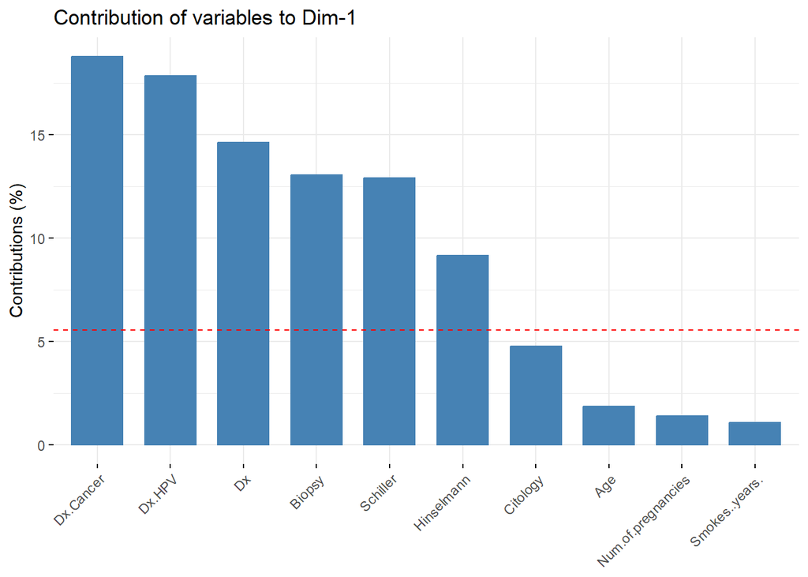

```r
#Contribución de las variables a las 3 primeras dimensiones
fviz_contrib(compPrinc, choice = "var", axes = 1, top = 10) #Dimensión 1
```

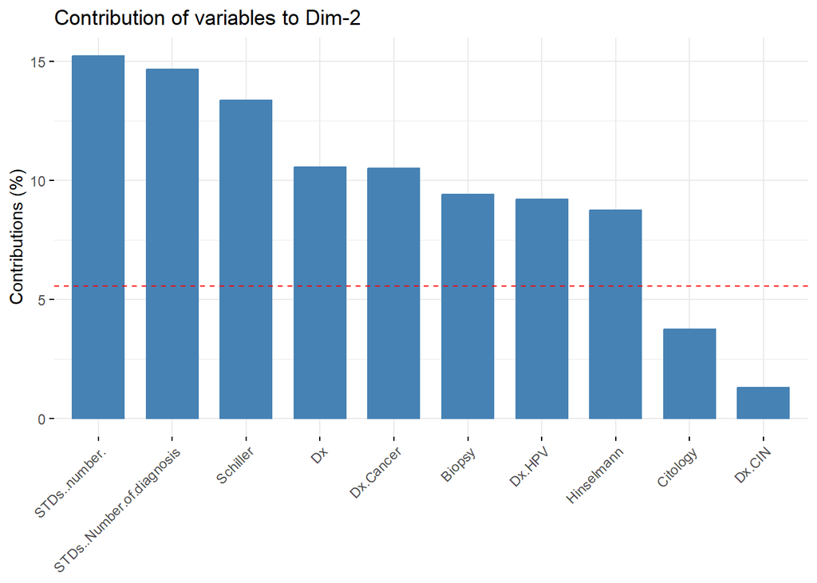

```r
fviz_contrib(compPrinc, choice = "var", axes = 2, top = 10) #Dimensión 2
```

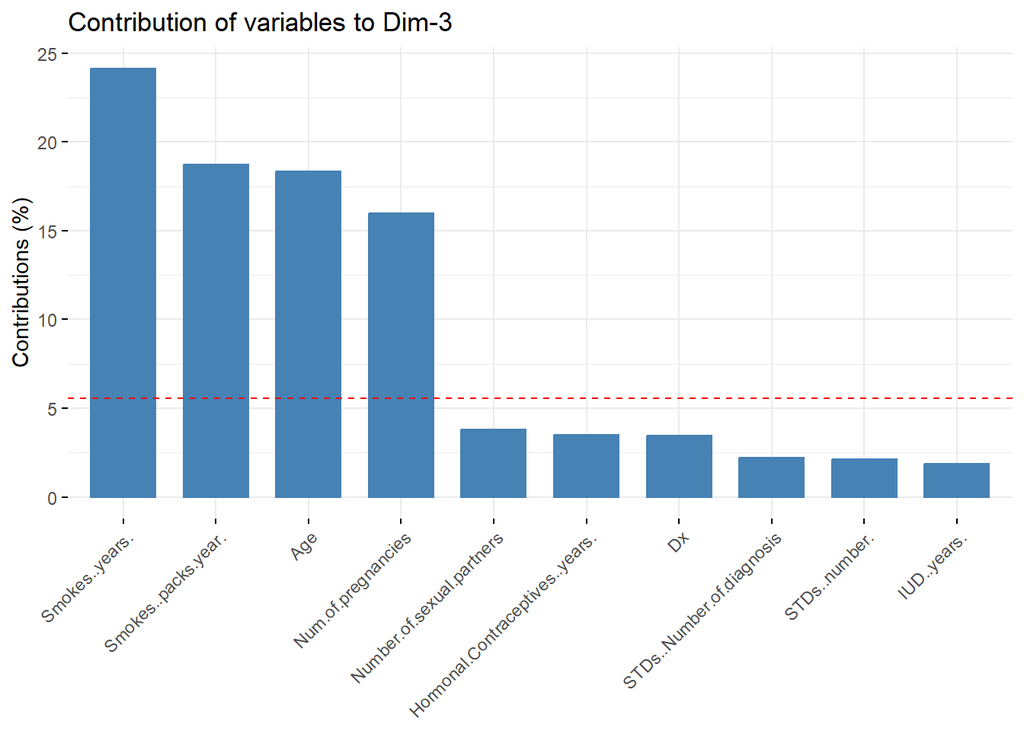

```r
fviz_contrib(compPrinc, choice = "var", axes = 3, top = 10) #Dimensión 3
```

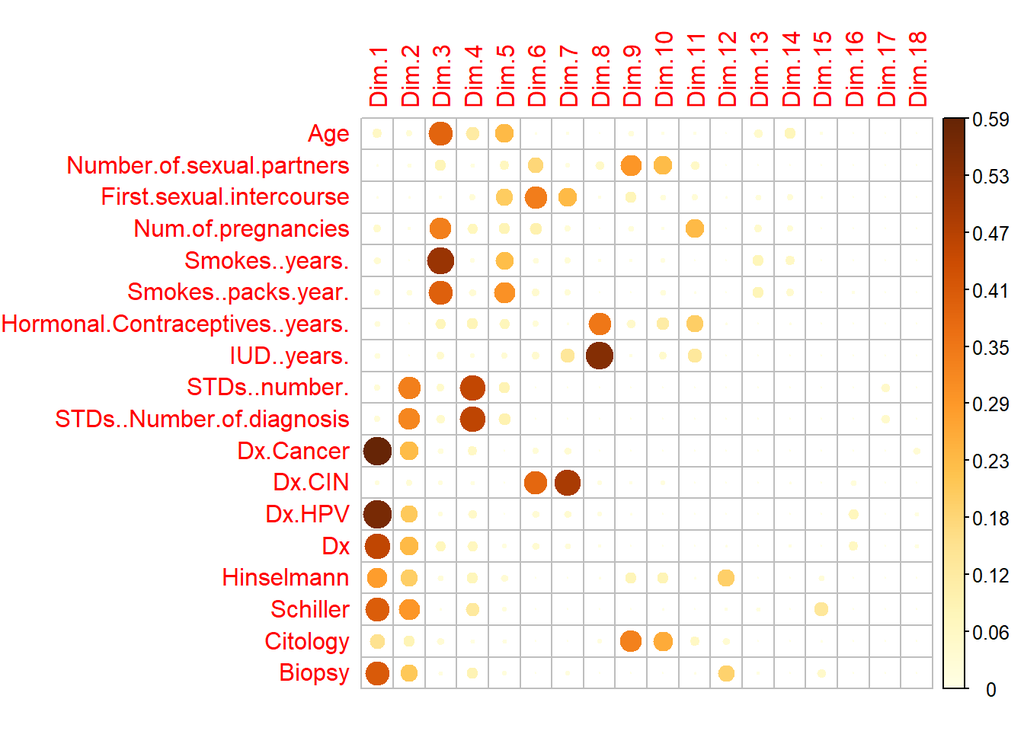

```r
var<-get_pca_var(compPrinc)
corrplot(var$cos2, is.corr = F)
```

### Conclusion

En conclusión, el análisis exploratorio realizado en el conjunto de datos “risk_factors_cervical_cancer.csv” nos ha permitido obtener una visión general de sus características y distribuciones. Primero, realizamos una exploración rápida de los datos, seleccionando las columnas de interés y transformando algunas de ellas a formato numérico. Luego, calculamos estadísticas descriptivas para las variables numéricas y tablas de frecuencias para las variables categóricas.

En cuanto a las variables numéricas, observamos que algunas de ellas presentan valores faltantes, lo que puede requerir un manejo adecuado de valores nulos en análisis posteriores. Además, identificamos posibles patrones de distribución en el histograma de “Num_of_pregnancies”, que nos proporciona información sobre la cantidad de embarazos en las pacientes.

Para las variables categóricas, generamos gráficas de barras y gráficos de torta para visualizar la distribución de las categorías y la proporción de cada clase. Notamos que algunas variables presentan una gran cantidad de valores nulos y que las clases están desbalanceadas en algunas variables, lo que puede afectar el rendimiento de ciertos modelos predictivos.

En cuanto al análisis de correlación, realizamos un estudio entre las variables numéricas, lo cual nos permitió identificar la presencia de multicolinealidad en los datos, lo que podría requerir técnicas adicionales de reducción de dimensionalidad, como PCA o MCA. Sin embargo, también encontramos que el KMO y el test de esfericidad de Bartlett sugieren que las variables numéricas están adecuadamente correlacionadas para realizar un análisis de componentes principales.

Para interpretar los coeficientes principales, se analizó la contribución de cada variable en cada dimensión. Se identificaron las características más relevantes en cada componente y se comprendió cómo cada variable contribuye a la formación de los componentes principales.

En cuanto a las reglas de asociación, se construyeron utilizando el algoritmo Apriori. Se realizaron pruebas con varios valores de confianza y soporte para evaluar la calidad y relevancia de las reglas generadas. Se tomó la decisión de mantener o eliminar características para obtener hallazgos más significativos. Se discutieron las reglas de asociación más interesantes, considerando sus niveles de confianza y soporte, lo que permitió identificar patrones y relaciones entre diferentes variables del conjunto de datos.

Finalmente, llevamos a cabo un análisis de componentes principales (PCA) con las variables numéricas completas. Los resultados del PCA mostraron que los primeros cinco componentes principales explican aproximadamente el 59.74% de la varianza total, lo que sugiere que una cantidad significativa de la varianza se puede explicar utilizando un número reducido de componentes. Además, mediante gráficos de contribución, identificamos las variables que más contribuyen a cada dimensión, lo que nos da una idea de las características más relevantes en cada componente.